# Software used in CS312

## Python 3

All of the coding in CS312 will be implimented using Python version 3. Python version 3.6+ is required for the course. Here is the Python 3 created by Microsoft [Python for Beginners](https://www.youtube.com/playlist?list=PLlrxD0HtieHhS8VzuMCfQD4uJ9yne1mE6). These videos are great for learning Python.

### Installing Python 3 Videos

- [Intro Python](https://www.youtube.com/watch?v=7XOhibxgBlQ&list=PLlrxD0HtieHhS8VzuMCfQD4uJ9yne1mE6&index=2)
- [Getting Started with Python](https://www.youtube.com/watch?v=CXZYvNRIAKM&list=PLlrxD0HtieHhS8VzuMCfQD4uJ9yne1mE6&index=4&t=0s)

### Verify Python Install

Open a command prompt or Mac terminal and type `python --version`. This should display the current version of Python that you have on your computer. Mac users might need to type `python3 --version`.

## Visual Studio Code

During the course, we will be using the text editor [Visual Studio Code](https://code.visualstudio.com/). It was selected because it's free and can run on Windows, Mac and Linux. You are free to use any editor that you want. However, I will be using VSCode during the course.

For Mac users, if you don't have the latest version of Python, after you install VSCode and try writing your first Python program, VSCode will display this warning. You must install the latest version of Python. Click on the "Download" button. After you download and install Python 3.8+, VSCode will ask you to select the Python version to use - select 3.8+.

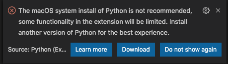

### Installing VSCode Videos

- [Configuring Visual Code](https://www.youtube.com/watch?v=EU8eayHWoZg&list=PLlrxD0HtieHhS8VzuMCfQD4uJ9yne1mE6&index=4)

### Verify Python setup in VSCode

1. Save this file anywhere on your computer,
2. In the bottom-left of VSCode, you will see the version of Python that is being used. If it's not the right version (ie., 3.7+), click on it to select a different version of Python.

[figure not shown]

### Installing Python Packages

The website `https://pypi.org/` contains Python packages.

When you installed Python 3 on your computer, the command `pip` was also installed. To make sure you have the latest version of `pip`, here are the commands:

- On Linux or macOS: `pip install -U pip`
- On Windows: `python -m pip install -U pip`

At the command prompt, type each of these commands to install the packages required for this course.

```
pip install opencv-python
pip install numpy
pip install matplotlib
```

### Python Extension for VSCode

There is a great Python extension for VSCode.

[figure not shown]

### MarkDown Extension

If you need to write MarkDown text, then this extension is perfect as it previews your markdown in real time.

[figure not shown]